# lab-02

COVID-19 Pandemic

[Matthew Coleman](https://matthewbcoleman.github.io/)

# Question 1

Top 5 Counties by Case Count

| County | Total Cases |
| --- | --- |
| Los Angeles | 225,827 |
| Riverside | 48,630 |
| Orange | 44,507 |
| San Bernardino | 42,947 |
| San Diego | 35,439 |

Top 5 Daily Case Counts

| Date | County | Daily Cases |
| --- | --- | --- |
| 2020-08-19 | Los Angeles | 1,796 |
| 2020-08-19 | San Bernardino | 797 |
| 2020-08-19 | Riverside | 430 |
| 2020-08-19 | Alameda | 382 |
| 2020-08-19 | Sonoma | 314 |

Top 5 Counties with Cummulative Cases per Capita

| County | Cummulative Cases per Capita |
| --- | --- |
| Imperial | 0.0568606 |
| Kings | 0.0368184 |
| Kern | 0.0301977 |
| Tulare | 0.0275335 |
| Merced | 0.0260336 |

Top 5 Daily Cummulative Cases per Capita

| Date | County | Daily Cases per Capita |
| --- | --- | --- |
| 2020-08-19 | Sonoma | 0.0006352 |
| 2020-08-19 | Kings | 0.0003662 |
| 2020-08-19 | San Bernardino | 0.0003656 |
| 2020-08-19 | Stanislaus | 0.0003450 |
| 2020-08-19 | Monterey | 0.0002834 |

### Analysis and Results

In the state, there have been a total of 646,742 cases and 6,243 new cases on 19 August 2020. The following counties are no longer on the California Watch list: **Alpine, Calaveras, Del Norte, El Dorado, Humboldt, Lake, Mariposa, Modoc, Mono, Nevada, Plumas, Shasta, Siskiyou, Trinity, Tuolumne**

# Question 2

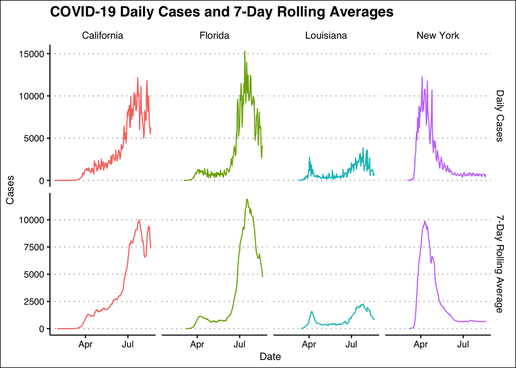

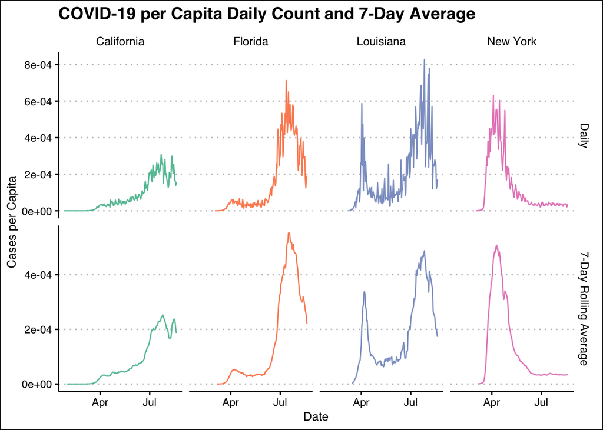

As we can see from the per-capita graph, accounting for population makes California no longer look like the worst state, and Louisiana no longer appears to be the best state. The daily cases per capita is about half of what the cases per capita is in Louisiana, despite the daily cases being less than a quarter.

# Question 3

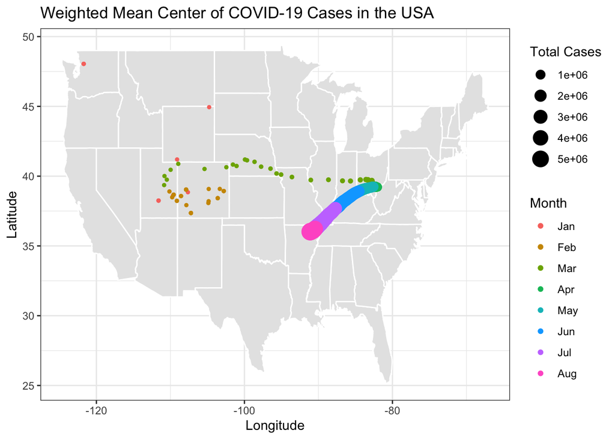

As we can see, the weighted mean began in Washington, where the first recorded case of COVID-19 was found. As spreading continued, the weighted mean shifted towards the East coast, which could easily be explained by the spike in cases in New York. More recently, the shift to the center and down can be attributed to increases in California and the Bible Belt.

# Code Appendix

```r
knitr::opts_chunk$set(echo = FALSE)
options(dplyr.summarise.inform=F)
library(tidyverse)
library(knitr)
library(readxl)
library(zoo)
library(kableExtra)
library(ggthemes)
library(RColorBrewer)
covid <- read_csv('https://raw.githubusercontent.com/nytimes/covid-19-data/master/us-counties.csv')



##############============================== QUESTION 1 ==============================##############

#California Table

ca_covid <- covid %>% filter(state == 'California') %>% group_by(county) %>% arrange(date, .by_group = TRUE ) %>% mutate(daily_cases =  (cases - lag(cases, default=first(cases)))) %>% ungroup()
ca_top_case <- ca_covid %>% group_by(county) %>% summarise(cases = max(cases)) %>% ungroup() %>% slice_max(cases,n=5)

ca_top_daily <- ca_covid %>% filter(date == max(date)) %>% slice_max(daily_cases, n=5) %>% select(date, county, daily_cases)

kable(ca_top_case, caption = 'Top 5 Counties by Case Count', col.names = c('County', 'Total Cases'), align = 'l', format.args = list(big.mark = ',')) %>% kable_styling()

kable(ca_top_daily, caption = 'Top 5 Daily Case Counts', col.names = c('Date', 'County', 'Daily Cases'), align = 'l', format.args = list(big.mark = ',')) %>% kable_styling()
population_2019 <- read_excel('../data/PopulationEstimates.xls', skip = 2) %>% select(State, Area_Name, fips = FIPStxt, pop_2019 = POP_ESTIMATE_2019)


ca_pop <- population_2019 %>% filter(State=='CA', Area_Name!='California')

ca_covid_pop <-  left_join(ca_covid, ca_pop, by = 'fips') %>%  group_by(county) %>%
  mutate(cases_per_capita = cases/pop_2019, new_cases_per_capita = daily_cases/pop_2019)

top_cases_per <- ca_covid_pop %>% group_by(county) %>% summarise(cases_per_capita = max(cases_per_capita)) %>% slice_max(cases_per_capita, n= 5)
#for some reason slice max refused to work with the new_cases_per_capita column after working with all the other columns so I had to do the brute force way
top_new_cases_arrange <- ca_covid_pop %>% filter(date ==max(date)) %>% arrange(-new_cases_per_capita)
top_new_cases_per <- top_new_cases_arrange[1:5,] %>% select(date, county, new_cases_per_capita)

kable(top_cases_per, caption = 'Top 5 Counties with Cummulative Cases per Capita', col.names = c('County', 'Cummulative Cases per Capita'), align = 'l', format.args = list(big.mark = ',')) %>% kable_styling()

kable(top_new_cases_per, caption = 'Top 5 Daily Cummulative Cases per Capita', col.names = c('Date', 'County', 'Daily Cases per Capita'), align = 'l', format.args = list(big.mark = ',')) %>% kable_styling()
ca_covid_14 <- ca_covid_pop %>% filter(date >= (max(date)-13))
ca_last_14_covid <- ca_covid_14 %>% group_by(county) %>% summarise(last_14_cases = sum(daily_cases), pop_2019 = mean(pop_2019)) %>%
  na.omit() %>% ungroup() %>% mutate(last_14_per_hundredk = (last_14_cases/pop_2019)*100000)

watchlist <- ca_last_14_covid %>% filter(last_14_per_hundredk >=100)
nonwatchlist <- ca_last_14_covid %>% filter(last_14_per_hundredk < 100)

watchlist_county <- watchlist %>% pull(county)
nonwatchlist_county <- nonwatchlist %>% pull(county)
df_cummulative_cases <- ca_covid %>% filter(date == max(date))

cummulative_cases <- sum(df_cummulative_cases$cases)
new_cummulative_cases <- sum(df_cummulative_cases$daily_cases)



##############============================== QUESTION 2 ==============================##############

states_four <- covid %>% filter(state %in% c('New York', 'California', 'Louisiana', 'Florida'))
states_totals <- states_four %>% group_by(state, date) %>% summarise(total_cases = sum(cases)) %>% mutate(daily_cases =  (total_cases - lag(total_cases, default=first(total_cases)))) %>% group_by(state) %>% mutate(rolling_mean = rollmean(daily_cases, 7, na.pad=TRUE, align = 'right')) %>% filter(daily_cases > 0)
long_state_totals <- states_totals %>% pivot_longer(cols = c('daily_cases', 'rolling_mean'), names_to = 'type')

type.labs <- c('Daily Cases', '7-Day Rolling Average')
names(type.labs) <- c('daily_cases', 'rolling_mean')

state_facet <- ggplot(long_state_totals, aes(x = date, y = value, color = state)) +
    geom_line() +
    facet_grid(type~state,
             scales = 'free_y',
             labeller = labeller(type = type.labs)) +
    labs(title = 'COVID-19 Daily Cases and 7-Day Rolling Averages',
         x = 'Date', y = 'Cases') +
    guides(color=F) +
    theme_clean()
state_facet
# Doing data cleaning and adding the new per-capita case count and the 7 day average of
# the per capita case count

state_pops <- population_2019 %>% filter(Area_Name %in% c('New York', 'California', 'Louisiana', 'Florida') )

state_cap_totals <- states_four %>% group_by(state, date) %>%
  summarise(total_cases = sum(cases)) %>%
  mutate(daily_cases =  (total_cases - lag(total_cases,
                                           default=first(total_cases)))) %>%
  inner_join(state_pops, by = c('state' = 'Area_Name')) %>%
  select(-c(State, fips)) %>%
  mutate(new_cases_per_capita = (daily_cases/pop_2019)) %>%
  group_by(state) %>%
  mutate(rolling_mean = rollmean(new_cases_per_capita, 7, na.pad=TRUE, align = 'right')) %>%
  filter(daily_cases > 0)

percap_state_totals <- state_cap_totals %>% pivot_longer(cols = c('new_cases_per_capita', 'rolling_mean'), names_to = 'type')

type.labs <- c('Daily', '7-Day Rolling Average')
names(type.labs) <- c('new_cases_per_capita', 'rolling_mean')

percap_state_facet <- ggplot(percap_state_totals, aes(x = date, y = value, color = state)) +
    geom_line() +
    facet_grid(type~state,
             scales = 'free_y',
             labeller = labeller(type = type.labs)) +
    labs(title = 'COVID-19 per Capita Daily Count and 7-Day Average',
         x = 'Date', y = 'Cases per Capita') +
    guides(color=F) +
    theme_clean() +
    scale_color_brewer(palette = 'Set2')
percap_state_facet



##############============================== QUESTION 3 ==============================##############

centroids <- read_csv("https://raw.githubusercontent.com/mikejohnson51/spds/master/docs/data/county-centroids.csv")

#Here I am going to impute the fips code for NYC because it is missing from the data, and NYC accounted for a large number of the cases so it is relevant to include.
covid$fips[which(covid$county == "New York City")] <- 36061
#covid_daily_raw <- covid %>% arrange(county, date) %>% group_by(county) %>% mutate(new_cases = c(first(cases), diff(cases))) %>% left_join(centroids, by = c('fips'))
covid_daily_raw <- covid %>% arrange(county, date) %>% group_by(county) %>% mutate(new_cases = c(first(cases), diff(cases))) %>%
  left_join(centroids, by = c('fips'))

covid_daily_clean <- covid_daily_raw[!(is.na(covid_daily_raw$LON)),]


#covid_daily_clean[(is.na(covid_daily_clean$LON)),]
covid_weighted <- covid_daily_clean %>% group_by(date) %>% summarise(weighted_lon = sum(LON*cases, na.rm = T)/sum(cases, na.rm = T),
                                                               weighted_lat = sum(LAT*cases, na.rm = T)/sum(cases, na.rm = T),
                                                               total_cases = sum(cases, na.rm = T),
                                                               new_totals = sum(new_cases, na.rm = T)) %>% ungroup()
covid_weighted$month <- factor(format(covid_weighted$date, '%b'), levels = month.abb)


#Map Plot
weighted_map <- ggplot(data = covid_weighted, aes(x=weighted_lon, y=weighted_lat)) +
  borders('state', fill = 'gray90', colour = 'white') +
  geom_point(aes(colour = month, size = total_cases)) +
  labs(title = 'Weighted Mean Center of COVID-19 Cases in the USA', x = 'Longitude', y = 'Latitude', size = 'Total Cases', colour = 'Month') +
  theme_bw()

weighted_map
```